# Markov Chain Monte Carlo

Diptanshu Singh

November 20, 2018

## Monte Carlo Methods

Markov chain Monte Carlo methods create samples from a possibly multi-dimensional continuous random variable, with probability density proportional to a known function. We cannot use the sampling distributions discussed earlier as the exact function is not known. We just know that the target is proportional to a known function.

## Independent Chain Sampler

This method generates a Markov chain using a proposal density for new steps and a method for rejecting some of the proposed moves. This markov chain can be used to approximate the distribution or to compute an integral (e.g. an expected value). Metropolis–Hastings is generally used for sampling from multi-dimensional distributions, especially when the number of dimensions is high.

This methods requires specifying the number of steps are needed. So we need to analyze how the chain is performing on different number of steps.

Distribution of variable ‘x’ are drawn from ~ [ Beta(a, b) and X where p ~ Binomial(n, p) ].

```r
x <- 8; n <- 10 # #heads, #flips

comparebeta <- function (f, x, n, a, b, ...) {
  p <- f(x, n, a, b, ...)
  op <- par(mfrow = c(2, 1))
  plot(p, type = "l")
  hist(p, freq = FALSE)
  t <- seq(0, 1, length = 100)
  lines(t, dbeta(t, x + a, n - x + b))
  par(op)
}

# Independent chain sampler
mhcoin <- function (x, n, a, b, ns = 1000) {
  p <- numeric(ns)
  p[1] <- a / (a + b)  # prior mean
  for (i in 2:ns) {
    pc <- rbeta(1, a, b) # candidate
    logR <- x * log(pc) + (n - x) * log(1 - pc) -
      (x * log(p[i - 1]) + (n - x) * log(1 - p[i - 1]))
    if (logR > 0 || log(runif(1)) < logR) # accept?
      p[i] <- pc
    else # reject
      p[i] <- p[i - 1]
  }
  p
}
```

Usually it is not hard to construct a Markov chain with the desired properties. The more difficult problem is to determine how many steps are needed to converge to the stationary distribution within an acceptable error. A good chain will have rapid mixing: the stationary distribution is reached quickly starting from an arbitrary position.

Sometimes, we also reject the initial part of the chain, as the function might not have explored the space still. (Not implemented here)

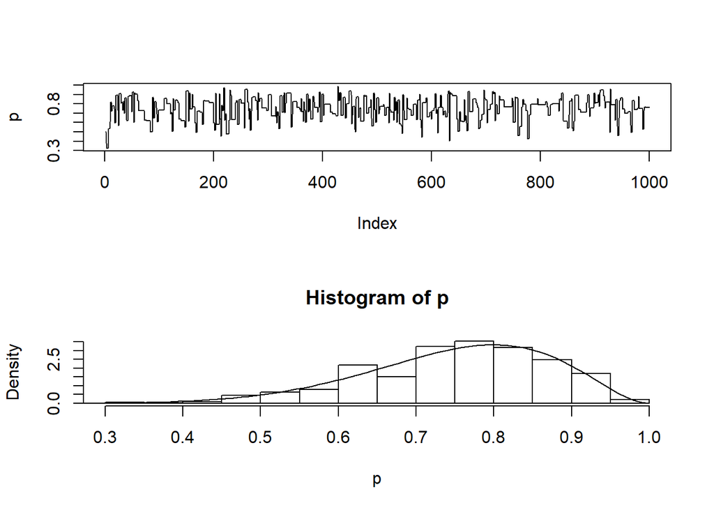

```r
a <-  1; b <-  1;
comparebeta(mhcoin, x, n, a, b)
```

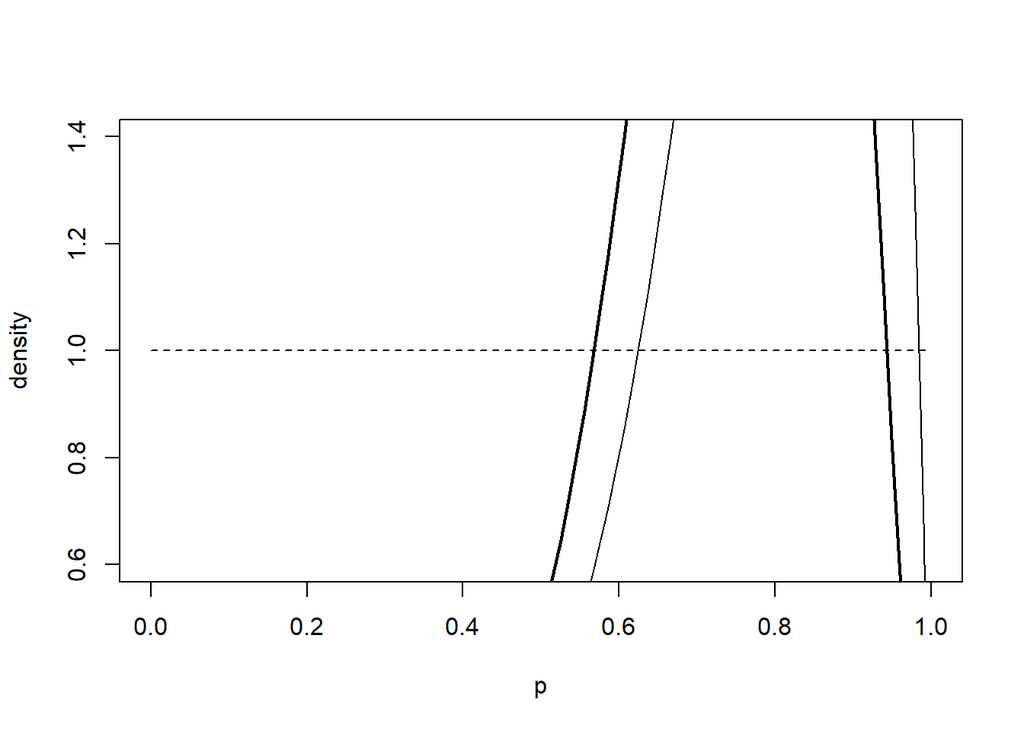

```r
t <- seq(0, 1, length = 100)
plot(t, dbeta(t, a, b), type = "l", lty = 2,
     xlab = "p", ylab = "density") # prior
lines(t, dbeta(t, x, n - x)) # normalized likelihood
lines(t, dbeta(t, a + x, n - x + b), lwd = 2) # posterior
```

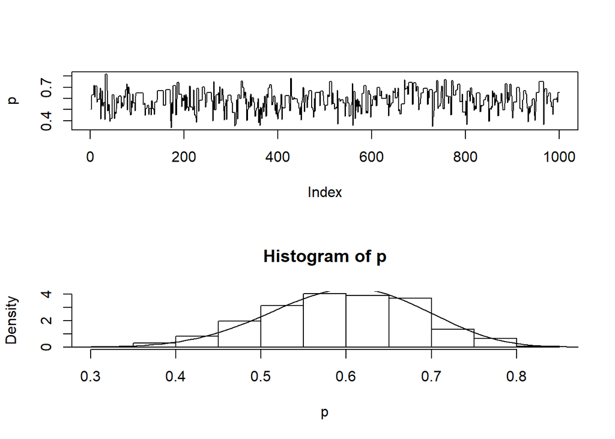

```r
# This chain mixes reasonably well


a <- 10; b <- 10;
comparebeta(mhcoin, x, n, a, b)
```

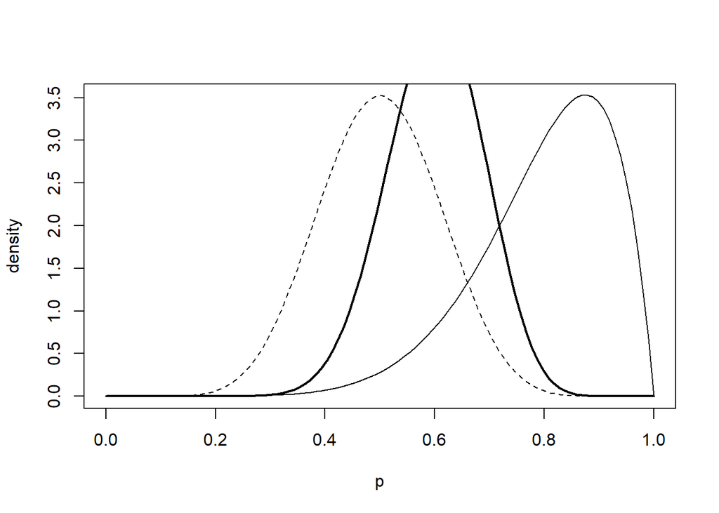

```r
t <- seq(0, 1, length = 100)
plot(t, dbeta(t, a, b), type = "l", lty = 2,
     xlab = "p", ylab = "density") # prior
lines(t, dbeta(t, x, n - x)) # normalized likelihood
lines(t, dbeta(t, a + x, n - x + b), lwd = 2) # posterior
```

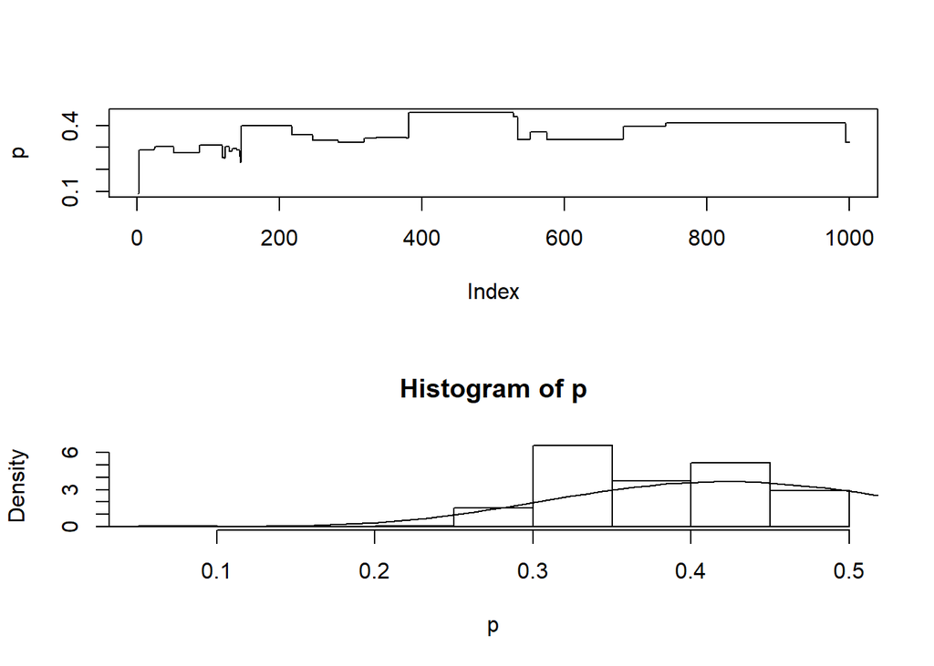

```r
# This chain mixes well, and is also exploring the entire space.


a <-  1; b <- 10;
comparebeta(mhcoin, x, n, a, b)
```

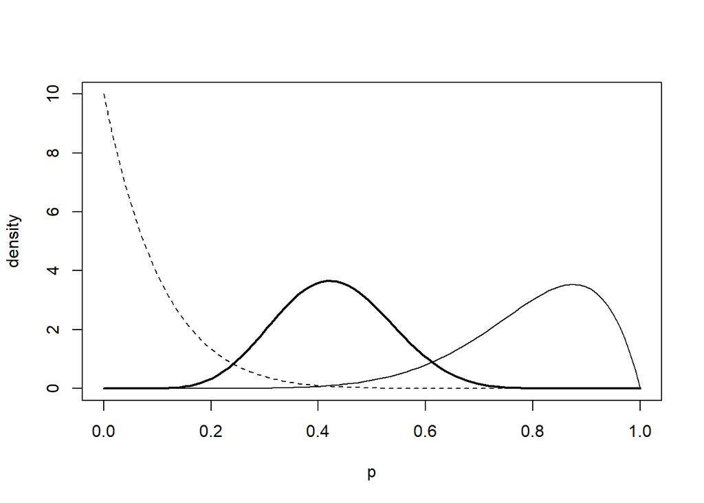

```r
t <- seq(0, 1, length = 100)
plot(t, dbeta(t, a, b), type = "l", lty = 2,
     xlab = "p", ylab = "density") # prior
lines(t, dbeta(t, x, n - x)) # normalized likelihood
lines(t, dbeta(t, a + x, n - x + b), lwd = 2) # posterior
```

```r
# This chain gets stuck in the local minima. The chain is not mixing well. Also the posterior distribution is far from the target density.
```

A standard empirical method to assess convergence is to run several independent simulated Markov chains and check that the ratio of inter-chain to intra-chain variances for all the parameters sampled is close to 1.

## Random Walk Sampler

Instead of specifying the number of steps required, we also specify the step size. This is done in the random walk algorithm. Constructing the algorithm for the same function -

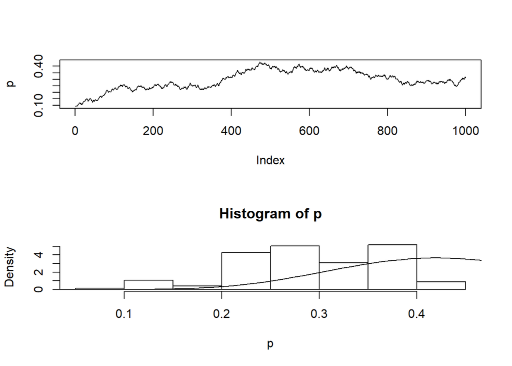

```r
a <-  1; b <- 10;
# Using the random walk sampler on the previous example where the independent chain sampler didn't work well.
rwcoin <- function (x, n, a, b, s = .01, ns = 1000) {
  p <- numeric(ns)
  p[1] <- a / (a + b)
  for (i in 2:ns) {
    pc <- p[i - 1] + runif(1, -s, s) # candidate
    if (pc < 0 || pc > 1) { # out of bounds?
      p[i] <- p[i - 1] # reject
      next
    }
    logR <- dbeta(pc, a + x, b + n - x, log = TRUE) -
      dbeta(p[i - 1], a + x, b + n - x, log = TRUE)
    if (logR > 0 || log(runif(1)) < logR) # accept?
      p[i] <- pc
    else
      p[i] <- p[i - 1]
  }
  p
}

comparebeta(rwcoin, x, n, a, b, .01)
```

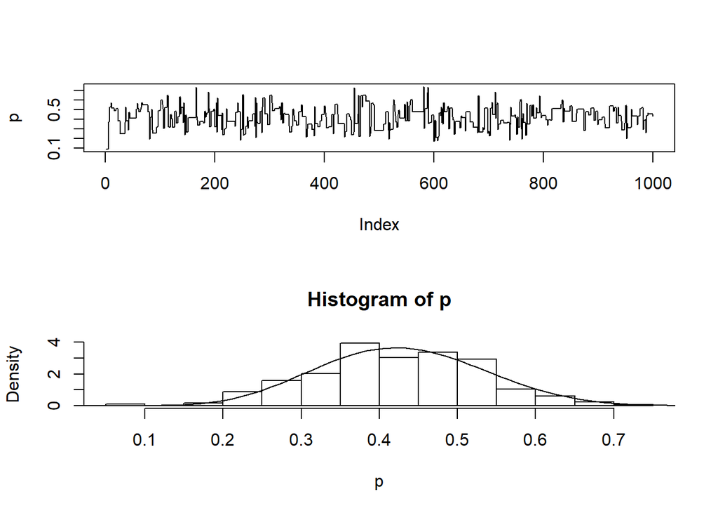

```r
# The random step is too small. There is slow drift
comparebeta(rwcoin, x, n, a, b, .50)
```

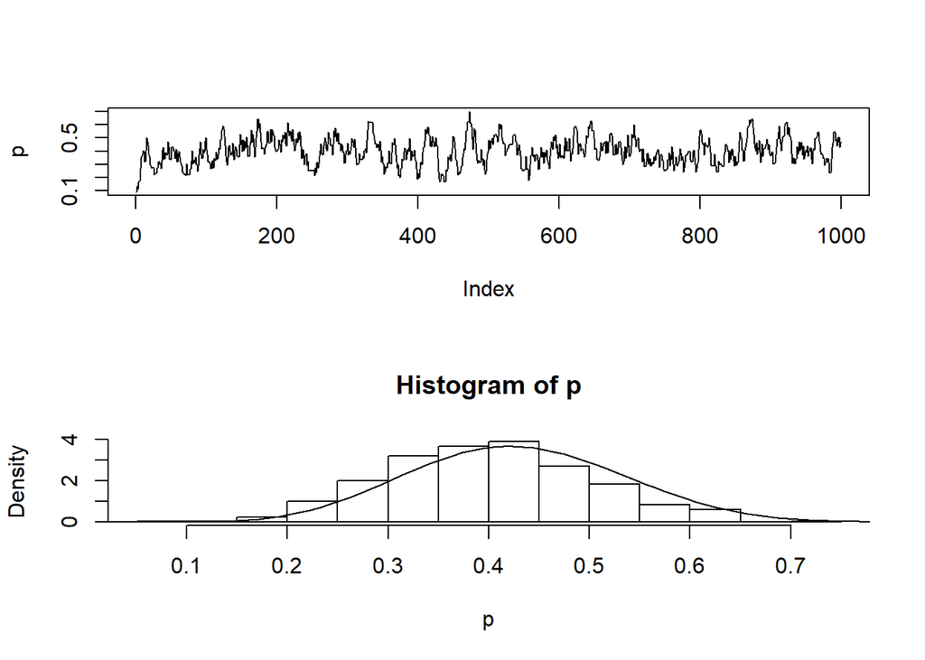

```r
# The random step is large, as a result it gets stuck once in a while
comparebeta(rwcoin, x, n, a, b, .10)
```

```r
# The random step is "just right". The posterior distribution is a good approximation of the target density.
```

## Gibbs Sampler

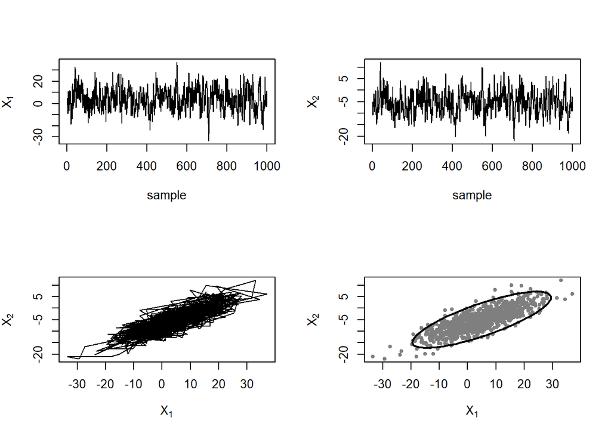

```r
mu <- c(5, -5)
sigma <- matrix(c(100, 40, 40, 25), nrow = 2)

# plot (x - mu)' * sigma^(-1) * (x - mu) = qchisq(alpha, 2)
ellipse <- function (mu, sigma, alpha = .95, ns = 100) {
  p <- matrix(nrow = 2, ncol = ns) # points
  t <- seq(0, 2 * pi, length = ns) # param (angle)
  e <- eigen(sigma)
  s <- sqrt(e$values * qchisq(alpha, 2))
  # scale
  p[1,] <- s[1] * cos(t)
  p[2,] <- s[2] * sin(t)
  e$vectors %*% p + mu
}


comparegaussian <- function (f, mu, sigma, ...) {
  x <- f(mu, sigma, ...)
  op <- par(mfrow = c(2, 2))
  plot(x[,1], type = "l", xlab = "sample", ylab = expression(X[1]))
  plot(x[,2], type = "l", xlab = "sample", ylab = expression(X[2]))
  plot(x[,1], x[,2], type = "l",
       xlab = expression(X[1]), ylab = expression(X[2]))
  plot(x[,1], x[,2],
       xlab = expression(X[1]), ylab = expression(X[2]),
       pch = 20, col = "gray50")
  p <- ellipse(mu, sigma)
  lines(p[1,], p[2,], lwd=2)
  par(op)
}


# Gibbs sampler
gibbsgaussian <- function (mu, sigma, ns = 1000) {
  x <- matrix(nrow = ns, ncol = 2)
  x[1,] <- mu
  for (i in 2:ns) {
    # x1 | x2
    m <- mu[1] + sigma[1, 2] / sigma[2, 2] * (x[i - 1, 2] - mu[2])
    s <- sqrt(sigma[1, 1] - sigma[1, 2] ^ 2 / sigma[2, 2])
    x[i, 1] <- rnorm(1, m, s)
    # x2 | x1
    m <- mu[2] + sigma[1, 2] / sigma[1, 1] * (x[i, 1] - mu[1])
    s <- sqrt(sigma[2, 2] - sigma[1, 2] ^ 2 / sigma[1, 1])
    x[i, 2] <- rnorm(1, m, s)
  }
  x
}

comparegaussian(gibbsgaussian, mu, sigma) # nice mixing
```